# **Personal Movement Analysis**

This is an Analysis Report as a part of the Project Assignment of the Reproducible Research Course. The data is collected from Personal Activity Monitoring Devices at 5-minute intervals from October and November, 2012.

## **Loading and Preprocessing the Data**

The dataset is stored in a comma-separated-value (CSV) file and there are a total of 17,568 observations in this dataset.

The variables included are:

- **steps:** Number of steps taking in a 5-minute interval(missing values:NA)
- **date:** The date on which the measurement was taken in YYYY-MM-DD format
- **interval:** Identifier for the 5-minute interval in which measurement was taken

### Reading the Dataset

```r
data<-read.csv("activity.csv")
data$date<-as.Date(data$date)
```

## **What is mean total number of steps taken per day?**

### 1.The total number of steps taken per day

```r
total.steps<-with(data,tapply(steps,date,sum,na.rm=TRUE))
df1<-data.frame(dates=names(total.steps),totalSteps=total.steps)
rownames(df1)<-seq(1,61,by=1)
head(df1)
```

```
##        dates totalSteps
## 1 2012-10-01          0
## 2 2012-10-02        126
## 3 2012-10-03      11352
## 4 2012-10-04      12116
## 5 2012-10-05      13294
## 6 2012-10-06      15420
```

### 2.Make a Histogram of total number of steps taken each day

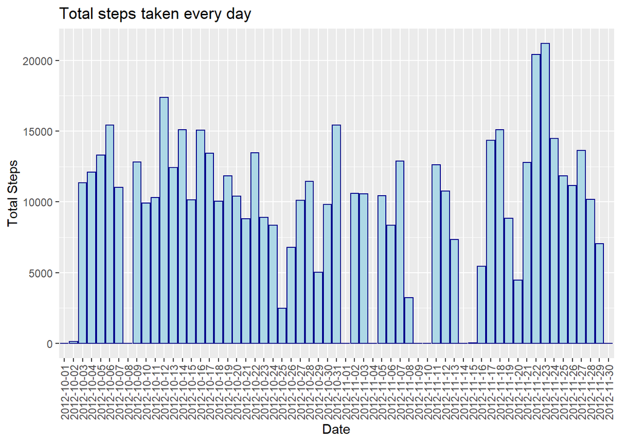

```r
library(ggplot2)
g<-ggplot(df1,aes(x=dates,y=totalSteps))+
    geom_bar(color="darkblue",fill="lightblue",stat="identity")+
    ggtitle("Total steps taken every day",)+xlab("Date")+ylab("Total Steps")+
    theme(axis.text.x = element_text(angle=90,vjust = 0.5))
print(g)
```

### 3. The mean and median of total number of steps taken per day

```r
mn.day<-mean(df1$totalSteps,na.rm = TRUE)
med.day<-median(df1$totalSteps,na.rm = TRUE)
```

- Mean is : **9354.2295082**
- Median is : **10395**

## **What is the average daily activity pattern?**

### 1. Time series plot of average number of steps for all intervals

```r
avg.int.steps<-with(data,tapply(steps,interval,mean,na.rm=TRUE))
df2<-data.frame(interval=names(avg.int.steps),averageSteps=avg.int.steps)
```

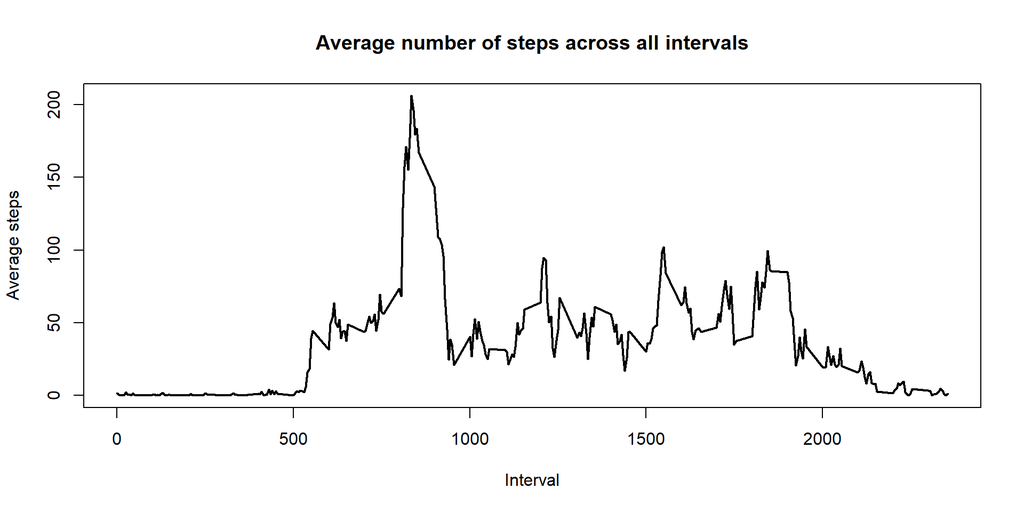

```r
#time-series plot
plot(df2$interval,df2$averageSteps,type="l",
     main = "Average number of steps across all intervals",xlab = "Interval",
     ylab="Average steps",lwd=2)
```

### 2. 5-minute interval containing maximum average number of steps taken.

```r
mx.mn.ind<-with(df2,which.max(averageSteps))
mx.mn.int<-df2[mx.mn.ind,"interval"]
mx.mn.val<-df2[mx.mn.ind,"averageSteps"]
```

Interval **835** has maximum number of average steps **206.1698113**..

## **Inputing missing values**

### 1.Total number of missing values(NA’s)

```r
miss<-sum(is.na(data$steps))
```

Total missing values are: **2304**.

### 2. Fill all the missing values in the dataset.

```r
logic.na<-which(is.na(data$steps))
logic.int<-data$interval[logic.na]

missval<-sapply(logic.int,function(x,db){
    db$averageSteps[which(x==db$interval)]
},db=df2)
```

### 3. New Dataset with NA’s filled with mean values of that particular interval.

```r
data2<-data
data2$steps[logic.na]=missval
na.val<-sum(is.na(data2$steps))
```

The total number of NA values now are: **0**.

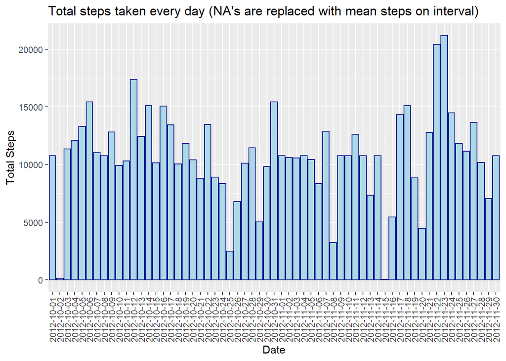

```r
total.steps.new<-with(data2,tapply(steps,date,sum,na.rm=TRUE))
df3<-data.frame(dates=names(total.steps.new),totalSteps=total.steps.new)

library(ggplot2)
g2<-ggplot(df3,aes(x=dates,y=totalSteps))+
    geom_bar(color="darkblue",fill="lightblue",stat="identity")+
    ggtitle("Total steps taken every day (NA's are replaced with mean steps on interval)",)+xlab("Date")+ylab("Total Steps")+
    theme(axis.text.x = element_text(angle=90,vjust = 0.5))
print(g2)
```

```r
mn.day.new<-mean(df3$totalSteps,na.rm = TRUE)
med.day.new<-median(df3$totalSteps,na.rm = TRUE)
```

## **Are there differences in activity patterns between weekdays and weekends?**

### 1. New Factor variable fct.week with data2.

```r
fct.week<-factor(ifelse(weekdays(data2$date) %in% c("Saturday","Sunday"),"weekend","weekday"))
data2<-cbind(data2,fct.week)
str(data2)
```

```
## 'data.frame':    17568 obs. of  4 variables:
##  $ steps   : num  1.717 0.3396 0.1321 0.1509 0.0755 ...
##  $ date    : Date, format: "2012-10-01" "2012-10-01" ...
##  $ interval: int  0 5 10 15 20 25 30 35 40 45 ...
##  $ fct.week: Factor w/ 2 levels "weekday","weekend": 1 1 1 1 1 1 1 1 1 1 ...
```

### 2. Panel Plot of time series interval and average steps across “weekday” and “weekend”.

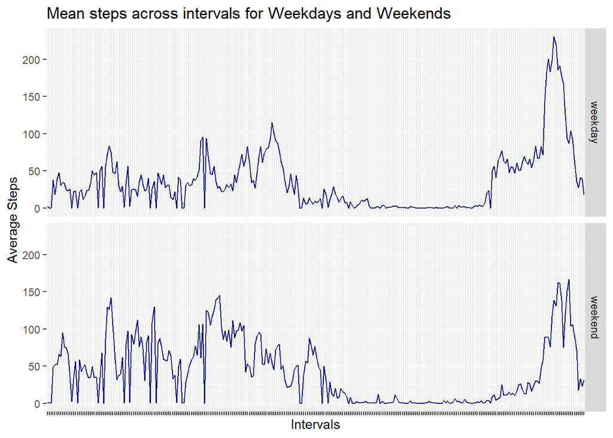

```r
spl.db<-split(data2,data2$fct.week)
reqd.values<-lapply(spl.db,function(x){
 tapply(x$steps,x$interval,mean,na.rm=TRUE)
})

df4<-data.frame(intervals=c(names(reqd.values[[1]]),names(reqd.values[[2]])),
                mean.steps=c(reqd.values[[1]],reqd.values[[2]]),
                fct.week=(as.factor(c(rep("weekday",length(reqd.values[[1]])),
                                   rep("weekend",length(reqd.values[[2]]))))))

##plot
g3<-ggplot(data=df4,aes(x=intervals,y=mean.steps,group=fct.week))+
    facet_grid(facets = fct.week~.)+
    geom_line(color="darkblue")+
    theme(axis.text.x = element_blank())+xlab("Intervals")+
    ylab("Average Steps")+ggtitle("Mean steps across intervals for Weekdays and Weekends")
print(g3)
```